# Assignment 2

Yoni Potter

2/13/2022

# Population Density around Stations - ETL Workflow

## Introduction

In this workflow, we will create a shapefile that classifies each station on the Minneapolis Green Line Extension (GLE) by population and by population density within its catchment area. This will be accomplished using open portal data (for stations), OpenStreetMap network data (to create network-based catchment areas, or isochrones), and U.S. Census Bureau data (for population counts). For reference, a map of the GLE is provided below.

[figure not shown]

**Figure 1:** The route map of the Green Line Extension (GLE) (Source: *Route and Stations*, n.d.)

## ETL workflow diagram

[video not shown]

**Figure 2:** ELT workflow for calculating population and population density around stations

**View static image in case embedded flowchart doesn’t work**

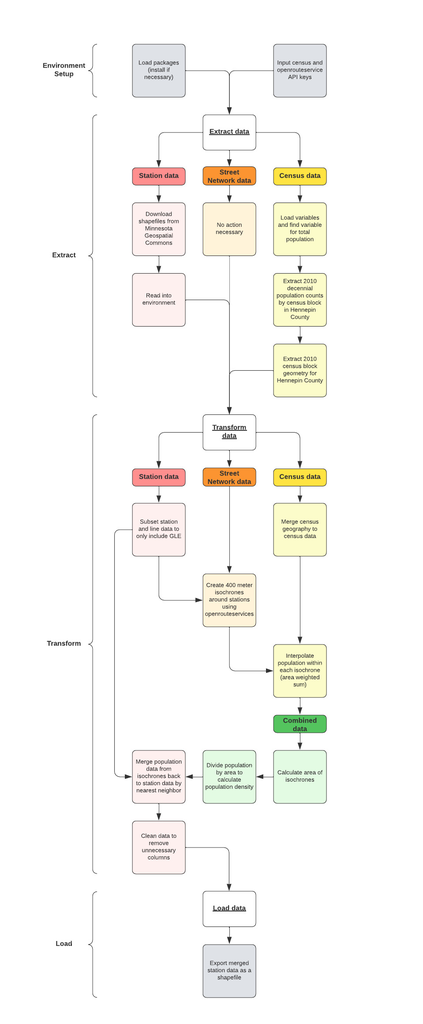

**Figure 2a:** ETL workflow in static image format

## Environment setup

First, we will load in all needed packages:

```r
library(sf)
library(dplyr)
library(stringr)
library(tidycensus)
library(tigris)
library(units)
library(tmap)
library(kableExtra)
```

Note that one package, **openrouteservice**, is not currently available in CRAN, and must be downloaded from Github using the **devtools** package. The installation line has been commented, as it has already been run.

```r
# Install devtools first, then use it to install openrouteservice from Github
library(devtools)
# devtools::install_github("GIScience/openrouteservice-r")
library(openrouteservice)
```

Finally, we need to input API keys for [**openrouteservice**](https://api.openrouteservice.org/) and [**tidycensus**](https://api.census.gov/data/key_signup.html). Actual API key inputs are not included.

```r
# Input ORS API key
# ors_api_key("")

# Input tidycensus API key
# census_api_key("")
```

## Extract

For this workflow, three data sources are needed:

- Station data from the Minnesota Geospatial Commons (Metropolitan Council 2022)
  - To be downloaded directly from the data portal
- Street network data from OpenStreetMap, in order to create isochrones (OpenStreetMap Contributors 2022)
  - To be accessed indirectly through the **openrouteservice** package
- Population data from the US Census Bureau (U.S. Census Bureau 2010)
  - To be accessed through the **tidycensus** package
  - Geographical data to be accessed through the **tigris** package, as **tidycensus** failed to load 2010 block geometry

### Station data - from Minnesota Geospatial Commons

First, we must extract the locations of the planned Green Line stations, as well as the route of the Green Line itself for visualization purposes. These data are available from the [Minnesota Geospatial Commons](https://gisdata.mn.gov/dataset/us-mn-state-metc-trans-transitways-generalized), but can also be downloaded directly from R. Downloading and unzipping lines were commented, as they have already been run.

```r
# download.file(url = "https://resources.gisdata.mn.gov/pub/gdrs/data/pub/us_mn_state_metc/trans_transitways_generalized/shp_trans_transitways_generalized.zip", destfile = "stations.zip")
# unzip(zipfile = "stations.zip", exdir = "stations")

# Read station and line shapefiles
RAW_stations <- read_sf("stations/TransitwayStationsGeneralizedLocations.shp")
RAW_lines <- read_sf("stations/TransitwayAlignmentsGeneralized.shp")
```

### Street network data

Because **openrouteservices** is able to access OpenStreetMap remotely, no street network data must be loaded directly into the R environment.

### Population data - from the US Census Bureau

Next, we use **tidycensus** to calculate the population of each census block in Hennepin County. The most recently available block-level data that were available were from 2010, so that was what was used.

First, in order to know which variable to use, we use the `load_variables` function, and then filter them to only include variables pertaining to total population.

```r
# Load variables
DEC10var <- load_variables(2010, "sf1", cache = TRUE)

# Filter to only include total population concepts, then display as table
DEC10var %>% filter(str_detect(concept, "TOTAL POPULATION")) %>% kbl() %>% kable_paper() %>% scroll_box(width = "100%", height = "400px")
```

| name | label | concept |
| --- | --- | --- |
| H010001 | Total | TOTAL POPULATION IN OCCUPIED HOUSING UNITS |
| H011001 | Total population in occupied housing units | TOTAL POPULATION IN OCCUPIED HOUSING UNITS BY TENURE |
| H011002 | Total population in occupied housing units!!Owned with a mortgage or a loan | TOTAL POPULATION IN OCCUPIED HOUSING UNITS BY TENURE |
| H011003 | Total population in occupied housing units!!Owned free and clear | TOTAL POPULATION IN OCCUPIED HOUSING UNITS BY TENURE |
| H011004 | Total population in occupied housing units!!Renter occupied | TOTAL POPULATION IN OCCUPIED HOUSING UNITS BY TENURE |
| H011A001 | Population in occupied housing units | TOTAL POPULATION IN OCCUPIED HOUSING UNITS BY TENURE (WHITE ALONE HOUSEHOLDER) |
| H011A002 | Population in occupied housing units!!Owned with a mortgage or a loan | TOTAL POPULATION IN OCCUPIED HOUSING UNITS BY TENURE (WHITE ALONE HOUSEHOLDER) |
| H011A003 | Population in occupied housing units!!Owned free and clear | TOTAL POPULATION IN OCCUPIED HOUSING UNITS BY TENURE (WHITE ALONE HOUSEHOLDER) |
| H011A004 | Population in occupied housing units!!Renter occupied | TOTAL POPULATION IN OCCUPIED HOUSING UNITS BY TENURE (WHITE ALONE HOUSEHOLDER) |
| H011B001 | Population in occupied housing units | TOTAL POPULATION IN OCCUPIED HOUSING UNITS BY TENURE (BLACK OR AFRICAN AMERICAN ALONE HOUSEHOLDER) |
| H011B002 | Population in occupied housing units!!Owned with a mortgage or a loan | TOTAL POPULATION IN OCCUPIED HOUSING UNITS BY TENURE (BLACK OR AFRICAN AMERICAN ALONE HOUSEHOLDER) |
| H011B003 | Population in occupied housing units!!Owned free and clear | TOTAL POPULATION IN OCCUPIED HOUSING UNITS BY TENURE (BLACK OR AFRICAN AMERICAN ALONE HOUSEHOLDER) |
| H011B004 | Population in occupied housing units!!Renter occupied | TOTAL POPULATION IN OCCUPIED HOUSING UNITS BY TENURE (BLACK OR AFRICAN AMERICAN ALONE HOUSEHOLDER) |
| H011C001 | Population in occupied housing units | TOTAL POPULATION IN OCCUPIED HOUSING UNITS BY TENURE (AMERICAN INDIAN AND ALASKA NATIVE ALONE HOUSEHOLDER) |
| H011C002 | Population in occupied housing units!!Owned with a mortgage or a loan | TOTAL POPULATION IN OCCUPIED HOUSING UNITS BY TENURE (AMERICAN INDIAN AND ALASKA NATIVE ALONE HOUSEHOLDER) |
| H011C003 | Population in occupied housing units!!Owned free and clear | TOTAL POPULATION IN OCCUPIED HOUSING UNITS BY TENURE (AMERICAN INDIAN AND ALASKA NATIVE ALONE HOUSEHOLDER) |
| H011C004 | Population in occupied housing units!!Renter occupied | TOTAL POPULATION IN OCCUPIED HOUSING UNITS BY TENURE (AMERICAN INDIAN AND ALASKA NATIVE ALONE HOUSEHOLDER) |
| H011D001 | Population in occupied housing units | TOTAL POPULATION IN OCCUPIED HOUSING UNITS BY TENURE (ASIAN ALONE HOUSEHOLDER) |
| H011D002 | Population in occupied housing units!!Owned with a mortgage or a loan | TOTAL POPULATION IN OCCUPIED HOUSING UNITS BY TENURE (ASIAN ALONE HOUSEHOLDER) |
| H011D003 | Population in occupied housing units!!Owned free and clear | TOTAL POPULATION IN OCCUPIED HOUSING UNITS BY TENURE (ASIAN ALONE HOUSEHOLDER) |
| H011D004 | Population in occupied housing units!!Renter occupied | TOTAL POPULATION IN OCCUPIED HOUSING UNITS BY TENURE (ASIAN ALONE HOUSEHOLDER) |
| H011E001 | Population in occupied housing units | TOTAL POPULATION IN OCCUPIED HOUSING UNITS BY TENURE (NATIVE HAWAIIAN AND OTHER PACIFIC ISLANDER ALONE HOUSEHOLDER) |
| H011E002 | Population in occupied housing units!!Owned with a mortgage or a loan | TOTAL POPULATION IN OCCUPIED HOUSING UNITS BY TENURE (NATIVE HAWAIIAN AND OTHER PACIFIC ISLANDER ALONE HOUSEHOLDER) |
| H011E003 | Population in occupied housing units!!Owned free and clear | TOTAL POPULATION IN OCCUPIED HOUSING UNITS BY TENURE (NATIVE HAWAIIAN AND OTHER PACIFIC ISLANDER ALONE HOUSEHOLDER) |
| H011E004 | Population in occupied housing units!!Renter occupied | TOTAL POPULATION IN OCCUPIED HOUSING UNITS BY TENURE (NATIVE HAWAIIAN AND OTHER PACIFIC ISLANDER ALONE HOUSEHOLDER) |
| H011F001 | Population in occupied housing units | TOTAL POPULATION IN OCCUPIED HOUSING UNITS BY TENURE (SOME OTHER RACE ALONE HOUSEHOLDER) |
| H011F002 | Population in occupied housing units!!Owned with a mortgage or a loan | TOTAL POPULATION IN OCCUPIED HOUSING UNITS BY TENURE (SOME OTHER RACE ALONE HOUSEHOLDER) |
| H011F003 | Population in occupied housing units!!Owned free and clear | TOTAL POPULATION IN OCCUPIED HOUSING UNITS BY TENURE (SOME OTHER RACE ALONE HOUSEHOLDER) |
| H011F004 | Population in occupied housing units!!Renter occupied | TOTAL POPULATION IN OCCUPIED HOUSING UNITS BY TENURE (SOME OTHER RACE ALONE HOUSEHOLDER) |
| H011G001 | Population in occupied housing units | TOTAL POPULATION IN OCCUPIED HOUSING UNITS BY TENURE (TWO OR MORE RACES HOUSEHOLDER) |
| H011G002 | Population in occupied housing units!!Owned with a mortgage or a loan | TOTAL POPULATION IN OCCUPIED HOUSING UNITS BY TENURE (TWO OR MORE RACES HOUSEHOLDER) |
| H011G003 | Population in occupied housing units!!Owned free and clear | TOTAL POPULATION IN OCCUPIED HOUSING UNITS BY TENURE (TWO OR MORE RACES HOUSEHOLDER) |
| H011G004 | Population in occupied housing units!!Renter occupied | TOTAL POPULATION IN OCCUPIED HOUSING UNITS BY TENURE (TWO OR MORE RACES HOUSEHOLDER) |
| H011H001 | Population in occupied housing units | TOTAL POPULATION IN OCCUPIED HOUSING UNITS BY TENURE (HISPANIC OR LATINO HOUSEHOLDER) |
| H011H002 | Population in occupied housing units!!Owned with a mortgage or a loan | TOTAL POPULATION IN OCCUPIED HOUSING UNITS BY TENURE (HISPANIC OR LATINO HOUSEHOLDER) |
| H011H003 | Population in occupied housing units!!Owned free and clear | TOTAL POPULATION IN OCCUPIED HOUSING UNITS BY TENURE (HISPANIC OR LATINO HOUSEHOLDER) |
| H011H004 | Population in occupied housing units!!Renter occupied | TOTAL POPULATION IN OCCUPIED HOUSING UNITS BY TENURE (HISPANIC OR LATINO HOUSEHOLDER) |
| H011I001 | Population in occupied housing units | TOTAL POPULATION IN OCCUPIED HOUSING UNITS BY TENURE (WHITE ALONE, NOT HISPANIC OR LATINO HOUSEHOLDER) |
| H011I002 | Population in occupied housing units!!Owned with a mortgage or a loan | TOTAL POPULATION IN OCCUPIED HOUSING UNITS BY TENURE (WHITE ALONE, NOT HISPANIC OR LATINO HOUSEHOLDER) |
| H011I003 | Population in occupied housing units!!Owned free and clear | TOTAL POPULATION IN OCCUPIED HOUSING UNITS BY TENURE (WHITE ALONE, NOT HISPANIC OR LATINO HOUSEHOLDER) |
| H011I004 | Population in occupied housing units!!Renter occupied | TOTAL POPULATION IN OCCUPIED HOUSING UNITS BY TENURE (WHITE ALONE, NOT HISPANIC OR LATINO HOUSEHOLDER) |
| P001001 | Total | TOTAL POPULATION |

Based on the list above, it seems that “P001001” is the correct variable. We thus extract this variable for all Hennepin County blocks in the 2010 decennial census.

```r
RAW_block_pop <- get_decennial(geography = "block",
                         variables = c(pop = "P001001"),
                         county = "Hennepin",
                         state = "MN",
                         year = 2010,
                         survey = "acs5",
                         geometry = FALSE,
                         output = "wide")
```

Finally, we use **tigris** to acquire census block geometry, as my attempts to include geometry through **tidycensus** did not succeed.

```r
RAW_block_geom <- blocks(state = "MN", county = "hennepin", year = 2010)
```

## Transform

In this section, the following operations are conducted:

- Subset stations and routes to only include the GLE
- Create isochrones around stations
- Merge census data to census geographies
- Interpolate population within station isochrones based on census data
- Calculate area of each isochrone, then use as a denominator for population to calculate population density
- Merge population and population density variables back to each station

### Station data

As the station and line data do not only cover the GLE, but the entire existing and planned Minneapolis-St. Paul LRT and BRT network, we need to subset the data to only include the GLE and its 16 stations.

First, we need to examine the data to see which rows to include.

```r
kbl(RAW_stations) %>% kable_paper() %>% scroll_box(width = "100%", height = "200px")
```

| NameStatio | MapLabel | Serves | Shared | PointUniqu | geometry |
| --- | --- | --- | --- | --- | --- |
| 10th St | 10th St | Green | 0 | 810BE895-72B7-4B46-BB7A-9D78250518CF | POINT (492299.2 4977481) |
| 10th St | 10th St | Rush | 0 | 3E81B90D-59C6-49DE-A72E-CCB1600464E0 | POINT (492534.1 4977550) |
| 11th St (2nd Ave) | 11th St (2nd Ave) | Orange | 0 | 83E704A3-E1ED-4744-9BBC-EB369949F6B1 | POINT (478463 4979807) |
| 11th St (Marquette) | 11th St (Marquette) | Orange | 0 | 18D58086-8186-400C-8F3C-16F23ADD1DAE | POINT (478369.6 4979892) |
| 140th St | 140th St | Red | 0 | 9F2BB69A-068D-4834-8C85-60D555BBFFFF | POINT (482769 4954987) |
| 147th St | 147th St | Red | 0 | 96DD844F-0DE8-41A7-B675-2E42DF2F3DD7 | POINT (482761.9 4953721) |
| 14th St | 14th St | Rush | 0 | BE01FC90-EE0C-435A-984B-81B207C33B32 | POINT (492368.5 4977964) |
| 161st St | 161st St | RedExt | 0 | 7869A3B5-7684-4FE9-8C57-7166610C0642 | POINT (482755.8 4951442) |
| 195th St | 195th St | RedExt | 0 | 231ACFC7-9863-486D-83EB-CA258F4C7AA6 | POINT (482761.2 4946041) |
| 215th St | 215th St | RedExt | 0 | B998431A-E7EA-4D01-8B15-4A27901903DD | POINT (482742.5 4942716) |
| 28th Ave | 28th Ave | Blue;Red | 1 | 0D0BB159-807D-4074-A37E-F7D45C85B9E8 | POINT (481705.2 4966964) |
| 38th St | 38th St | Blue | 0 | CAD5504A-0A68-4CDA-B23C-EE3AA3A7D765 | POINT (481896.6 4975717) |
| 3rd St (2nd Ave) | 3rd St (2nd Ave) | Orange | 0 | A7082D5E-8A6C-4B78-A357-479D4E6B106B | POINT (479021.1 4980745) |
| 3rd St (Marquette) | 3rd St (Marquette) | Orange | 0 | E26366CA-671E-42CB-8B79-1C76D877BE62 | POINT (478886.3 4980766) |
| 44th Ave & Girard | 44th Ave and Girard | D | 0 | 828F1B9E-6DA1-40F9-815F-9474BD92B354 | POINT (476544.1 4986931) |
| 44th Avenue & Penn | 44th Avenue and Penn | D | 0 | 88D72F38-2632-42C6-9162-DE53C9E4B38D | POINT (475752.4 4986935) |
| 46th St | 46th St | Orange | 0 | B74355F7-48C8-4522-896F-271107E91E5F | POINT (478315.3 4974063) |
| 46th St & 46th Ave | 46th St and 46th Ave | A | 0 | 6A2D67F1-8461-4ED3-AEF8-9352BA351E1C | POINT (483594.6 4974053) |
| 46th St & Minnehaha | 46th St and Minnehaha | A | 0 | D722B17D-99A9-47AD-95EC-B40DB3A76E63 | POINT (483015.2 4974052) |
| 46th St Station | 46th St | A;Blue | 1 | 19461F5C-21BE-46F3-88C8-DE3008A423B0 | POINT (482623.9 4974187) |
| 50th St/Minnehaha Park | 50th St/Minnehaha Park | Blue | 0 | AFF52A0E-7123-4E28-9244-5EA61DE1FCB6 | POINT (483416.9 4973235) |
| 5th St | 5th St | Gold;Rush | 1 | 7B4D0D92-3D16-494F-8C53-CEC06BC1D053 | POINT (492862.5 4977126) |
| 5th St (2nd Ave) | 5th St (2nd Ave) | Orange | 0 | 3D264D40-8060-4EDD-A1A7-E35855731CFB | POINT (478897.3 4980535) |
| 5th St (Marquette) | 5th St (Marquette) | Orange | 0 | 0AA5D0AF-1EA8-45AF-B5FE-BBC01FEB756E | POINT (478759.5 4980550) |
| 5th St/Cedar Street | 5th St/Cedar Street | Gold | 0 | D2B6C0B9-07A7-4493-9BF2-C191FF2801B2 | POINT (492692.5 4977009) |
| 63rd Ave | 63rd Ave | BlueExt | 0 | C73E3421-9E5A-4E3B-86BC-0E9466E11102 | POINT (470960 4990818) |
| 66th St | 66th St | Orange | 0 | FDE73E51-A4DE-4C38-AAE9-84608DA3D67D | POINT (476618.2 4970043) |
| 6th St | 6th St | Gold;Rush | 1 | 2440BB9A-A2F6-49A3-822A-2EBC3909E8E0 | POINT (492854.5 4977265) |
| 76th St | 76th St | Orange | 0 | 9B2325E8-DBCF-4649-90B1-07CA8E61AB6E | POINT (476118.9 4968027) |
| 7th St & 3rd/4th Ave | 7th St and 3rd/4th Ave | C;D | 1 | B2EC2438-0AEC-439F-8CF9-70156E9B5A7B | POINT (478906.9 4980195) |

[output cut: 187 more lines]

```r
kbl(RAW_lines) %>% kable_paper() %>% scroll_box(width = "100%", height = "200px")
```

| NameTransi | Transitway | Mode | FundingSce | OfficialMi | LastOffici | LastOffi_1 | Shape_Leng | geometry |
| --- | --- | --- | --- | --- | --- | --- | --- | --- |
| West Broadway/Cedar | Additional ABRT Candidate | Arterial Bus Rapid Transit | Increased Revenue | 0.0 | Metro Transit | 2021 | 24655.166 | MULTILINESTRING ((481385.9 … |
| 63rd Avenue/Zane | Additional ABRT Candidate | Arterial Bus Rapid Transit | Increased Revenue | 0.0 | Metro Transit | 2021 | 11787.218 | MULTILINESTRING ((474942.7 … |
| F Line | Planned | Arterial Bus Rapid Transit | Current Revenue | 0.0 | Metro Transit | 2021 | 23985.704 | MULTILINESTRING ((478201.1 … |
| H Line | Near-Term ABRT | Arterial Bus Rapid Transit | Increased Revenue | 0.0 | Metro Transit | 2021 | 33226.226 | MULTILINESTRING ((498939.4 … |
| Grand | Additional ABRT Candidate | Arterial Bus Rapid Transit | Increased Revenue | 0.0 | Metro Transit | 2021 | 20581.571 | MULTILINESTRING ((490296.5 … |
| Johnson/Lyndale | Additional ABRT Candidate | Arterial Bus Rapid Transit | Increased Revenue | 0.0 | Metro Transit | 2021 | 34310.029 | MULTILINESTRING ((475622.1 … |
| Lowry | Additional ABRT Candidate | Arterial Bus Rapid Transit | Increased Revenue | 0.0 | Metro Transit | 2021 | 21834.093 | MULTILINESTRING ((477430.2 … |
| Nicollet | Additional ABRT Candidate | Arterial Bus Rapid Transit | Increased Revenue | 0.0 | Metro Transit | 2021 | 23997.594 | MULTILINESTRING ((478312.9 … |
| Randolph/East 7th | Additional ABRT Candidate | Arterial Bus Rapid Transit | Increased Revenue | 0.0 | Metro Transit | 2021 | 20742.214 | MULTILINESTRING ((491861.1 … |
| G Line | Planned | Arterial Bus Rapid Transit | Current Revenue | 0.0 | Metro Transit | 2021 | 20689.322 | MULTILINESTRING ((493629.9 … |
| A Line | Existing | Arterial Bus Rapid Transit | Current Revenue | 10.7 | Metropolitan Council | 2017 | 17274.788 | MULTILINESTRING ((482623.9 … |
| B Line | Planned | Arterial Bus Rapid Transit | Current Revenue | 8.2 | Metropolitan Council | 2019 | 25339.702 | MULTILINESTRING ((474092.7 … |
| Blue Line | Existing | Light Rail | Current Revenue | 12.0 | Metropolitan Council | 2004 | 19586.487 | MULTILINESTRING ((481120.7 … |
| Blue Line Extension | Planned | Light Rail | Current Revenue | 13.2 | Metropolitan Council | 2020 | 21428.886 | MULTILINESTRING ((478124.6 … |
| C Line | Existing | Arterial Bus Rapid Transit | Current Revenue | 10.1 | Metropolitan Council | 2019 | 16316.517 | MULTILINESTRING ((477869.4 … |
| D Line | Planned | Arterial Bus Rapid Transit | Current Revenue | 18.0 | Metropolitan Council | 2020 | 34070.182 | MULTILINESTRING ((479327.8 … |
| E Line | Planned | Arterial Bus Rapid Transit | Current Revenue | 19.7 | Metropolitan Council | 2020 | 25664.175 | MULTILINESTRING ((474586.6 … |
| Gold Line | Planned | Dedicated Bus Rapid Transit | Current Revenue | 10.0 | Metropolitan Council | 2020 | 18009.217 | MULTILINESTRING ((503074.6 … |
| Green Line | Existing | Light Rail | Current Revenue | 11.2 | Metropolitan Council | 2014 | 17691.840 | MULTILINESTRING ((492726.5 … |
| Green Line Extension | Planned | Light Rail | Current Revenue | 14.5 | Metropolitan Council | 2020 | 23603.085 | MULTILINESTRING ((464841.9 … |
| Highway 169 | Project With Study Recommendations | Highway Bus Rapid Transit | Increased Revenue | 0.0 | Minnesota Department of Transportation | 2018 | 44449.456 | MULTILINESTRING ((459789.8 … |
| Highway 36 | Under Study/To Be Studied | Undetermined | Increased Revenue | 0.0 | Washington County | 2014 | 42776.062 | MULTILINESTRING ((515815.4 … |
| I-35 W North | Under Study/To Be Studied | Undetermined | Increased Revenue | 0.0 | Metropolitan Counil | 2016 | 25420.814 | MULTILINESTRING ((479920.1 … |
| I-394/Hwy 55 (Option A) | Under Study/To Be Studied | Undetermined | Increased Revenue | 0.0 | Metropolitan Council | 2015 | 18473.249 | MULTILINESTRING ((462017.9 … |
| I-394/Hwy 55 (Option B) | Under Study/To Be Studied | Undetermined | Increased Revenue | 0.0 | Metropolitan Council | 2015 | 21498.224 | MULTILINESTRING ((458319 49… |
| I-94 West | Under Study/To Be Studied | Undetermined | Increased Revenue | 0.0 | Metropolitan Council | 2014 | 23752.529 | MULTILINESTRING ((464911.3 … |
| Midtown | Project With Study Recommendations | Light Rail | Increased Revenue | 4.4 | City of Minneapolis | 2014 | 7122.455 | MULTILINESTRING ((474414.8 … |
| Nicollet-Central | Project With Study Recommendations | Modern Streetcar | Increased Revenue | 3.7 | City of Minneapolis | 2013 | 7257.949 | MULTILINESTRING ((478963.5 … |
| North Central | Under Study/To Be Studied | Undetermined | Increased Revenue | 0.0 | Minnesota Department of Transportation | 2014 | 24238.560 | MULTILINESTRING ((477048.2 … |
| Northstar | Existing | Commuter Rail | Current Revenue | 40.0 | Metropolitan Council | 2009 | 62424.219 | MULTILINESTRING ((478143.5 … |
| Orange Line | Existing | Highway Bus Rapid Transit | Current Revenue | 17.1 | Metropolitan Council | 2018 | 30584.878 | MULTILINESTRING ((476951.5 … |
| Orange Line Extension | Project With Study Recommendations | Highway Bus Rapid Transit | Increased Revenue | 6.0 | Dakota County | 2019 | 7316.913 | MULTILINESTRING ((477290.3 … |
| Red Line | Existing | Highway Bus Rapid Transit | Current Revenue | 10.0 | Metropolitan Council | 2013 | 17194.124 | MULTILINESTRING ((480491.6 … |
| Red Line Extension | Project With Study Recommendations | Highway Bus Rapid Transit | Increased Revenue | 0.0 | Dakota County | 2015 | 9827.835 | MULTILINESTRING ((482741.9 … |
| Red Rock | Project With Study Recommendations | Highway Bus Rapid Transit | Increased Revenue | 20.1 | Washington County | 2016 | 33328.656 | MULTILINESTRING ((493361.8 … |
| Riverview | Planned | Modern Streetcar | Current Revenue | 11.7 | Ramsey County | 2019 | 19109.699 | MULTILINESTRING ((481120.7 … |
| Purple Line | Planned | Dedicated Bus Rapid Transit | Current Revenue | 14.9 | Ramsey County | 2017 | 24856.631 | MULTILINESTRING ((493361.8 … |
| American Boulevard | Under Study/To Be Studied | Arterial Bus Rapid Transit | Increased Revenue | 0.0 | Metropolitan Council | 2012 | 19134.106 | MULTILINESTRING ((481218.1 … |

From the tables above, it appears that we only need to include rows in `RAW_stations` where `Serves` is `GreenExt`,[^1] and rows in `RAW_lines` where `NameTransi` is `Green Line Extension`. The **dplyr** `filter` function will be used to do this.

```r
GLE_stations <- RAW_stations %>% filter(Serves == "GreenExt")
GLE_line <- RAW_lines %>% filter(NameTransi == "Green Line Extension")
```

Before moving on, we should quickly view the result to make sure that it matches up with **Figure 1** above.

```r
# Set tmap mode to interactive viewing
tmap_mode("view")
```

```
## tmap mode set to interactive viewing
```

```r
# Create map
tm_shape(GLE_line) + tm_lines() +
  tm_shape(GLE_stations) + tm_dots()
```

[interactive chart not shown]

**Figure 3:** The route and stations of the GLE, as extracted and filtered from the Minnesota Geospatial Commons

The resulting map does appear to match **Figure 1**.

### Street network data - isochrones

The next step is to create isochrones around each station. They are like buffers, but based on actual street network distances, rather than Euclidean distance. Thus, areas that are nearby stations but are inaccessible by road networks will not be included.

However, for **openrouteservice** to be able to calculate isochrones, the data must be transformed into EPSG:4326.

```r
GLE_stations1 <- st_transform(GLE_stations, 4326)
GLE_line1 <- st_transform(GLE_line, 4326)
```

Next, we create isochrones using the coordinates of the stations.[^2] Walking distances are set to 400 meters, which is roughly equivalent to 1/4 mile, a fairly common buffer distance used in public transportation research (as per my literature review).

Unfortunately, we can only calculate 5 at a time due to API limitations. Thus, we have to run `ors_isochrones` in four batches, fix the indices of each batch so they do not overlap, and then bind them together. Finally, we have to make the geometry of the isochrones valid with `st_make_valid`, as one isochrone’s geometry does not produce a valid shape.

```r
i1 <- ors_isochrones(st_coordinates(GLE_stations1[1:5, ]), profile = "foot-walking", range_type = "distance", range = 400, output = "sf")
i2 <- ors_isochrones(st_coordinates(GLE_stations1[6:10, ]), profile = "foot-walking", range_type = "distance", range = 400, output = "sf")
i3 <- ors_isochrones(st_coordinates(GLE_stations1[11:15, ]), profile = "foot-walking", range_type = "distance", range = 400, output = "sf")
i4 <- ors_isochrones(st_coordinates(GLE_stations1[16, ]), profile = "foot-walking", range_type = "distance", range = 400, output = "sf")

# Make index values unique
i2$group_index <- i2$group_index + 5
i3$group_index <- i3$group_index + 10
i4$group_index <- i4$group_index + 15

# Bind rows together and fix an invalid geometry
GLE_isochrones <- rbind(i1, i2, i3, i4) %>% st_make_valid()
```

Plotting the isochrones:

```r
tm_shape(GLE_line1) + tm_lines() +
  tm_shape(GLE_stations1) + tm_dots() +
  tm_shape(GLE_isochrones) + tm_fill(col = "black", alpha = 0.5)
```

[interactive chart not shown]

**Figure 4:** 400-meter isochrones around each station

### Population data

Before we can assign census data to the isochrones, we need to merge our census data to our census geographies. This can be done simply with the ’merge` function. Extraneous columns are removed for simplicity. To avoid geographic overlay issues with isochrones, we will also transform the CRS to EPSG:4326.

```r
# Merge census geographies to census data, and then convert to sf object
MERGED_block <- merge(RAW_block_pop[ , c("GEOID", "pop")], RAW_block_geom[ , c("GEOID10")], by.x = "GEOID", by.y = "GEOID10") %>% st_as_sf()

# Transform CRS
MERGED_block1 <- st_transform(MERGED_block, 4326)
```

Now that we have one object containing both census block population and geography, we can assign population values to each isochrone through interpolation. We will use spatially extensive interpolation (a sum of unstandardized counts), as our goal is to approximate the total population within each isochrone.[^3]

```r
GLE_isochrones_interpolated <- st_interpolate_aw(MERGED_block1["pop"], GLE_isochrones, ext = TRUE)
```

In order to make population data spatially intensive, we have to divide the population of each isochrone by the isochrone’s area.

```r
# Calculate area of each isochrone in km^2
GLE_isochrones_interpolated$area <- st_area(GLE_isochrones_interpolated) %>% set_units(km^2)

# Calculate population density per km^2
GLE_isochrones_interpolated$popDensKM2 <- GLE_isochrones_interpolated$pop / GLE_isochrones_interpolated$area
```

### Putting it all together - merging isochrone data back to stations

Unfortunately, due to limitations in the **openrouteservices** package, station identifiers could not be kept when creating isochrones, and thus data from the isochrones will have to be joined back to the stations spatially. We can use the operation `st_nearest_feature`, which matches a point either to an isochrone it is within, or to the nearest isochrone available (necessary because not all stations exist on road networks, and thus may be excluded from their own isochrones).

```r
MERGED_stations <- st_join(GLE_stations1, GLE_isochrones_interpolated, join = st_nearest_feature)
```

Finally, we can place the `geometry` column last and remove unnecessary columns with **dplyr** functions.

```r
MERGED_stations <- MERGED_stations %>%
  relocate(geometry, .after = popDensKM2) %>%
  select(-MapLabel, -Serves, -Shared, -PointUniqu)
```

To view the data:

```r
kbl(MERGED_stations) %>% kable_paper() %>% scroll_box(width = "100%", height = "400px")
```

| NameStatio | pop | area | popDensKM2 | geometry |
| --- | --- | --- | --- | --- |
| Bassett Creek Valley | 0.255738 | 0.20672362 [km^2] | 1.237101 [1/km^2] | POINT (-93.29565 44.97435) |
| Beltline Blvd | 229.124371 | 0.28059259 [km^2] | 816.573147 [1/km^2] | POINT (-93.33941 44.94378) |
| Blake Road | 542.660007 | 0.25087472 [km^2] | 2163.071684 [1/km^2] | POINT (-93.3864 44.92781) |
| Bryn Mawr | 78.001001 | 0.17599946 [km^2] | 443.188871 [1/km^2] | POINT (-93.30916 44.96805) |
| City West | 27.359574 | 0.04364956 [km^2] | 626.800676 [1/km^2] | POINT (-93.41101 44.89053) |
| Downtown Hopkins | 449.627874 | 0.20953404 [km^2] | 2145.846420 [1/km^2] | POINT (-93.40919 44.92076) |
| Eden Prairie Town Center | 69.300347 | 0.06239929 [km^2] | 1110.595114 [1/km^2] | POINT (-93.43125 44.85911) |
| Golden Triangle | 55.170316 | 0.18025014 [km^2] | 306.076403 [1/km^2] | POINT (-93.41009 44.87728) |
| Louisiana Ave | 7.975575 | 0.13007630 [km^2] | 61.314590 [1/km^2] | POINT (-93.36507 44.93484) |
| Opus | 79.975871 | 0.25739119 [km^2] | 310.717201 [1/km^2] | POINT (-93.41393 44.89782) |
| Royalston Ave/Farmers Market | 750.880453 | 0.21656418 [km^2] | 3467.242146 [1/km^2] | POINT (-93.28303 44.9813) |
| Shady Oak | 0.000000 | 0.12135021 [km^2] | 0.000000 [1/km^2] | POINT (-93.42101 44.91776) |
| SouthWest Station | 149.794127 | 0.07730000 [km^2] | 1937.828186 [1/km^2] | POINT (-93.44442 44.8599) |
| West 21st St | 295.939012 | 0.22044203 [km^2] | 1342.479999 [1/km^2] | POINT (-93.31464 44.96063) |
| West Lake St | 479.344593 | 0.13537514 [km^2] | 3540.861372 [1/km^2] | POINT (-93.32433 44.94773) |
| Wooddale Ave | 331.585310 | 0.17995531 [km^2] | 1842.598104 [1/km^2] | POINT (-93.35478 44.93857) |

## Load

The last step, to load the data, is very simple. We must simply use the write_sf function. The function is commented, as it has already been run.

```r
# write_sf(MERGED_stations, "output/station_pop.shp")
```

## Acknowledgements

OpenrouteService data © openrouteservice.org by HeiGIT and available from https://openrouteservice.org/

OpenStreetMap map data © OpenStreetMap contributors (available under the Open Database License: https://opendatacommons.org/licenses/odbl/) and available from https://www.openstreetmap.org

## References

Metropolitan Council. (2022). *Transitways Generalized (Alignments and Stations)* [Data set]. Minnesota Geospatial Commons.https://gisdata.mn.gov/dataset/us-mn-state-metc-trans-transitways-generalized

*Route and Stations*. (n.d.). Metropolitan Council. Retrieved January 30, 2022, from https://metrocouncil.org/Transportation/Projects/Light-Rail-Projects/METRO-Green-Line-Extension/Route-Stations.aspx

U.S. Census Bureau. (2010). *2010 Decennial Census*

[^1]: Although some transfer stations are listed separately under the `Serves` column, the GLE does not include any new transfer stations.
[^2]: Unfortunately, `ors_isochrones` cannot use the actual station **sf** object.
[^3]: It should be noted that interpolation does not account for internal variation within census blocks, and thus is subject to some uncertainty.